# Sampling and Integration

${\bf \large \cal Hovhannes \ Grigoryan}\\ {\rm \small New \ York, \ NY}$

### Abstract

We start by showing one of the ways one can sample gaussian distribution from uniform distribution. Then we show how to sample points uniformly on a sphere and on a ball, using either direct sampling or Markov-chain sampling. The latter algorithm allows to implement something like a *random walk* on a sphere. We discuss how *Metropolis acceptance probability* in Markov-chain method can be used to sample points from an arbitrary distribution, and other competing algorithms using direct sampling. We also discuss rejection free tower sampling and Walker algorithms. We consider an example of inverse square root distribution, and discuss how to solve problems associated with it. We conclude by calculating volume and area of the d-dimensional hypersphere using Monte Carlo methods [1].

### Content

> - *Gaussian Distribution from Uniform Distribution*
> - *Direct way to uniformly sample points on a unit sphere*
> - *Sampling uniform distribution inside the unit ball*
> - *Metropolis Acceptance Probability*
> - *Direct Sampling Rejection Cut Algorithm*
> - *Tower Sampling Method (rejection free)*
> - *Walker Algorithm*
> - *Calculation of High Dimensional Integrals Using Monte Carlo Methods*

### References

[1] We closely follow the outline of lectures by *W. Krauth, et al., "Statistical Mechanics: Algorithms and Computations".* OUP Oxford, 2006

```python
%%html
<style>
body, p, div.rendered_html {
    color: black;
    font-family: "Times Roman", sans-serif;
    font-size: 12pt;
}
</style>
```

```python
from __future__ import division
import random
import numpy as np
from itertools import combinations

%precision 20

%matplotlib inline
%config InlineBackend.figure_format = 'retina'

import matplotlib.pyplot as plt
from matplotlib import animation, rc, cm
from mpl_toolkits.mplot3d import axes3d, Axes3D

from IPython.display import HTML, Image, clear_output

plt.rcParams['figure.figsize'] = (14,8)
plt.style.use('fivethirtyeight')
rc('animation', html='html5')

import warnings
warnings.filterwarnings('ignore')

import sys, os
sys.path.append(os.path.abspath(os.path.join('..')))

from utils.make_gif import make_gif, clear_data
from utils.html_converter import html_converter
```

Consider the example of estimating $\pi$ from P1. We can do this either by sampling or by integration:

- Monte Carlo: $\frac{\pi}{4} \approx \frac{N_{hits}}{N_{trials}} = \frac{1}{N_{trials}} \sum_i O_i $
- Integration: $\frac{\pi}{4} = \frac{\int^1_{-1}\int^1_{-1} dxdy~ O(x,y)\pi(x,y)}{\int^1_{-1}\int^1_{-1} dxdy~\pi(x,y)}$
- $O(x,y) = \left\{\begin{array}{ll} 1 & \mbox{if $x^2+y^2 \leq 1$},\\ 0 & \mbox{if $x^2+y^2 > 1$}.\end{array}\right.$

where, $\pi(x,y)=1$ is uniform probability density inside the square. It is clear that Monte Carlo sampling methods should excel at higher dimensions.

### Gaussian Distribution from Uniform Distribution

Consider 1D gaussian integral $I = \int^\infty_{-\infty}\frac{\text{d}x}{\sqrt{2\pi}}e^{-x^2/2}$, which is known to be 1. We calculate it as follows:

$I^2=\int^\infty_{-\infty}\frac{\text{d}y}{\sqrt{2\pi}} \int^\infty_{-\infty}\frac{\text{d}x}{\sqrt{2\pi}}e^{-(x^2+y^2)/2}=\int^{2\pi}_0 \frac {\text{d}\phi}{2\pi}\int^\infty_0 r e^{-r^2/2} \text{d}r =\int^{2\pi}_0 \frac {\text{d}\phi}{2\pi}\int^\infty_0 e^{-\psi} \text{d}\psi = \int^{2\pi}_0 \frac {\text{d}\phi}{2\pi}\int^1_0 \text{d}\Upsilon=1$,

where $x=r \cos\phi$, $y = r \sin \phi$, $\psi = r^2/2$, $\Upsilon = e^{-\psi}$

The variable transformations indicate a transformation between uniformly distributed random variables $\Upsilon, \phi$ and gaussian distributed random variables $x, y$. Changes of variables in integrals also apply to samples. This is a relation between the integration variables on the exponent of the gaussian and the gaussian distributed random variables. (This is by no means the only way to sample gaussian distribution from uniform distribution.)

```python
def gauss_test(sigma):
    phi = random.uniform(0.0, 2.0 * np.pi)
    Upsilon = random.uniform(0.0, 1.0)
    Psi = - np.log(Upsilon)
    r = sigma * np.sqrt(2.0 * Psi)
    x = r * np.cos(phi)
    y = r * np.sin(phi)
    return [x, y]
```

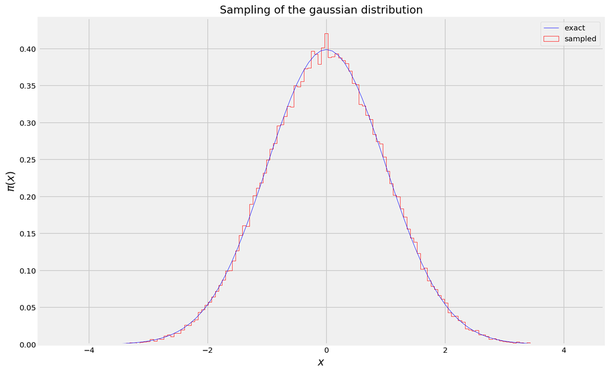

```python
# exact distrubution:
list_x = [i * 0.1 for i in range(-40, 40)]
list_y = [np.exp(- x ** 2 / 2.0) / (np.sqrt(2.0 * np.pi)) for x in list_x]

# sampled distribution:
n_sampled_pairs = 50000
data = []

for sample in range(n_sampled_pairs):
    data += gauss_test(1.0)

# graphics output
fig = plt.figure(figsize=(12,8))
plt.plot(list_x, list_y, color='b', label='exact', lw=0.5)
plt.hist(data, bins=150, density=True, color='r', histtype='step', label='sampled');
plt.legend()
plt.title('Sampling of the gaussian distribution')
plt.xlabel('$x$', fontsize=14)
plt.ylabel('$\pi(x)$', fontsize=14)
plt.show()
```

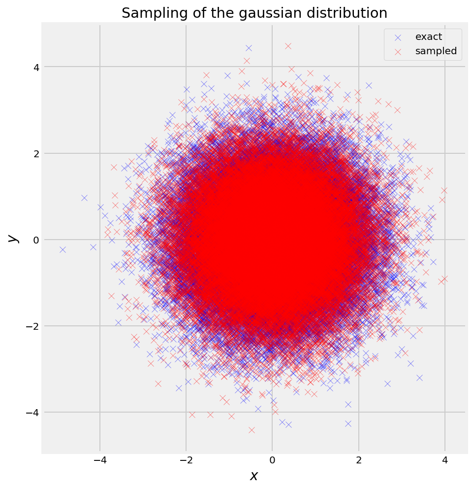

```python
# sampled distribution:
n_sampled_pairs = 50000
data = []

for sample in range(n_sampled_pairs):
    data.append(gauss_test(1.0))

X = np.random.randn(n_sampled_pairs)
Y = np.random.randn(n_sampled_pairs)

fig = plt.figure(figsize=(8,8))
plt.scatter(X, Y, color='b', label='exact', lw=0.3, alpha=0.7, marker='x') # by 'exact' we mean generated by a better algorithm
plt.scatter(np.array(data)[:,0], np.array(data)[:,1], color='r', label='sampled', lw=0.3, alpha=0.7, marker='x')
plt.legend()
plt.title('Sampling of the gaussian distribution')
plt.axis('scaled')
plt.xlabel('$x$', fontsize=14)
plt.ylabel('$y$', fontsize=14)
plt.show()
```

### Direct way to sample points on a unit sphere

As was shown above, change of variables in the integral affects the distribution of samples. Therefore,

$1 = I^d= \left(\frac{1}{\sqrt{2\pi}}\right)^d \int^{\infty}_{-\infty} \dots \int^{\infty}_{-\infty}\text{d}x_0 \dots \text{d}x_{d-1} e^{-(x_0^2+ \dots + x^2_{d-1})/2} = \left(\frac{1}{\sqrt{2\pi}}\right)^d \int^\infty_{0} \text{d}r~ r^{d-1} e^{-r^2/2} \int \text{d}\Omega_{d-1} $

where we went from cartesian $(x_0, \dots, x_{d-1})$ to polar coordinates $(r, \Omega_{d-1})$. Therefore, we can implement the following algorithm to uniformly sample the surface of the sphere.

```python
def plot_samples(x_list, y_list, z_list):
    fig = plt.figure(figsize=(10,10))
    ax = fig.gca(projection='3d')
    ax.set_aspect('equal')
    plt.plot(x_list, y_list, z_list, '.')
    plt.title('Uniform sampling of the sphere surface')
    ax.set_xlabel('$x$', fontsize=14)
    ax.set_ylabel('$y$', fontsize=14)
    ax.set_zlabel('$z$', fontsize=14)
    plt.show()
```

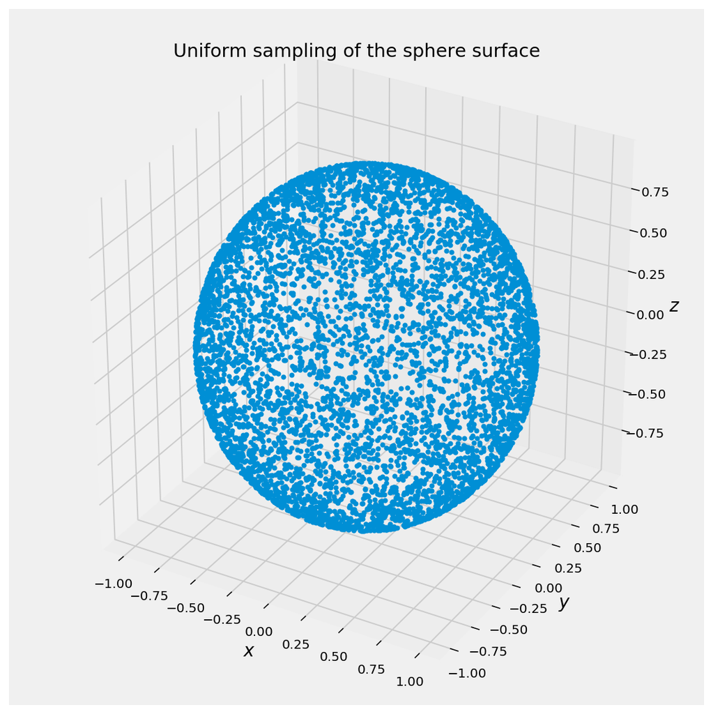

```
Wall time: 310 ms
```

```python
%%time
nsamples = 6000

x_list, y_list, z_list = [], [], []
for sample in range(nsamples):
    x, y, z = random.gauss(0.0, 1.0), random.gauss(0.0, 1.0), random.gauss(0.0, 1.0)
    radius = np.sqrt(x ** 2 + y ** 2 + z ** 2)
    x_list.append(x / radius)
    y_list.append(y / radius)
    z_list.append(z / radius)

# graphics output
plot_samples(x_list, y_list, z_list)
```

Another implementation of the same code.

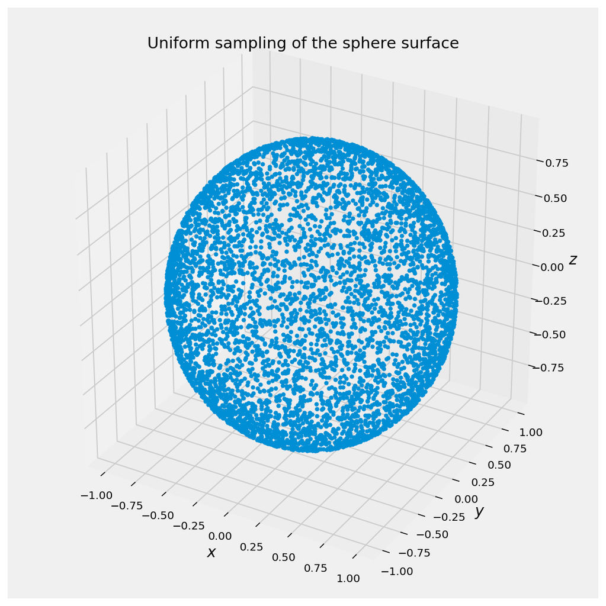

```
Wall time: 294 ms
```

```python
%%time
xyz = np.random.randn(nsamples, 3)
lens = np.linalg.norm(xyz, axis=1)
xyz_normed = xyz/lens.reshape(-1,1)
x_list, y_list, z_list = xyz_normed[:, 0], xyz_normed[:, 1], xyz_normed[:, 2]

# graphics output
plot_samples(x_list, y_list, z_list)
```

### Markov-chain algorithm on the surface of a d-dimensional unit sphere

```python
d = 3  # dimension
delta = 0.2  # step size
sigma = 1.0/np.sqrt(d)

n_samples = 4000
data = []

x = np.random.randn(d)
x /= np.linalg.norm(x)

for _ in range(n_samples):
    x = x.copy()
    eps = sigma * np.random.randn(d)
    P = np.dot(eps, x)
    eps -= P * x
    eps /= np.linalg.norm(eps)
    Upsilon = random.uniform(-delta, delta)
    x += Upsilon * eps
    x /= np.linalg.norm(x)  # we assume that |x|=0 case is highly unlikely
    data.append(x)
```

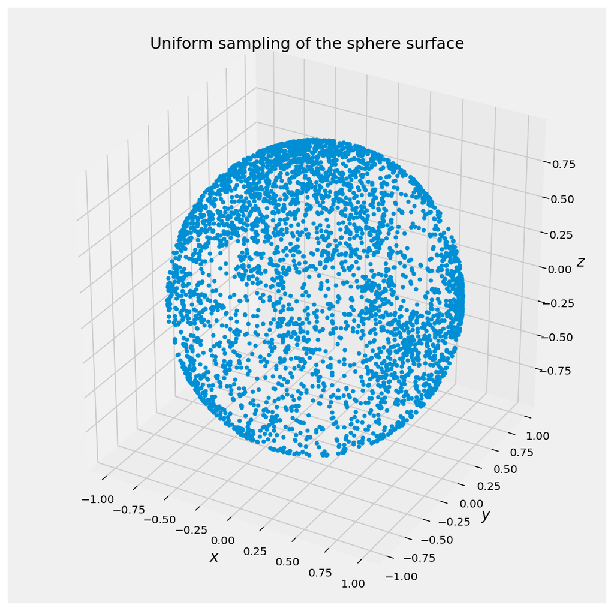

```python
adata = np.array(data)
x_list, y_list, z_list = adata[:, 0], adata[:, 1], adata[:, 2]

# graphics output
plot_samples(x_list, y_list, z_list)
```

### Markov-chain random moves on a surface of a sphere

```python
def plot3D_markov_sphere(old_data, new_point, step, save=False):
    fig = plt.figure(figsize=(10, 10))
    grid = plt.GridSpec(8, 4, hspace=0.3, wspace=0.1)

    # set up the axes for the first plot
    ax = fig.add_subplot(grid[:-1, 1:], projection='3d')

    # draw sphere
    u, v = np.mgrid[0:2*np.pi:200j, 0:np.pi:100j]
    x = np.cos(u)*np.sin(v)
    y = np.sin(u)*np.sin(v)
    z = np.cos(v)
    ax.plot_surface(x, y, z, rstride=1, cstride=1, cmap=cm.coolwarm,
                           linewidth=0, antialiased=False, alpha=0.2)

    # keep past points
    xa, ya, za = np.array(X), np.array(Y), np.array(Z)
    ax.plot(xa, ya, za, 'k.', alpha=0.4)

    # draw new point
    x_n, y_n, z_n = x_new
    ax.plot([x_n], [y_n], [z_n], 'ro')
    plt.title('Random walk on the sphere t='+step, fontsize=18)
    ax.set_xlabel('$x$', fontsize=18)
    ax.set_ylabel('$y$', fontsize=18)
    ax.set_zlabel('$z$', fontsize=18)
    ax.set_xlim(-1, 1)
    ax.set_ylim(-1, 1)
    ax.set_zlim(-1, 1)
    ax.set_aspect('equal')

    theta = np.arccos(za/np.sqrt(xa**2 + ya**2 + za**2))
    phi = np.arctan(ya/xa)
    tt = np.linspace(0, np.pi, 100)
    dist_theta = 0.5*np.sin(tt)

    ax2 = fig.add_subplot(grid[:-1, 0])
    ax2.hist(theta, bins=20, density=True, histtype='stepfilled', orientation='horizontal')
    ax2.plot(dist_theta, tt, 'k--', label="$0.5 \sin(\\theta)$")
    ax2.set_ylim(0, np.pi)
    ax2.legend(loc="upper right")
    ax2.invert_yaxis()
    plt.title('Polar angle ($\\theta$)', fontsize=18)

    ax3 = fig.add_subplot(grid[-1, 1:])
    ax3.hist(phi, bins=20, density=True, histtype='stepfilled', orientation='vertical')
    ax3.set_xlim(-np.pi/2, np.pi/2)
    ax3.invert_xaxis()
    plt.title('Azimuthal angle ($\phi$)', fontsize=18)
    if save:
        plt.savefig('../data/random_walk_sphere_t='+step+'.png', transparent=True)
    plt.show()


def plot2D_markov_sphere(old_data, new_point, step, save=False):
    plt.rcParams['figure.figsize'] = (18, 10)

    # set up a figure twice as wide as it is tall
    fig = plt.figure(figsize=plt.figaspect(0.5))

    # set up the axes for the first plot
    ax = fig.add_subplot(1, 2, 1)

    # keep past points
    X, Y = old_data
    xa, ya = np.array(X), np.array(Y)
    ax.plot(xa, ya, 'k.', alpha=0.4)

    # draw new point
    x_n, y_n = new_point
    ax.plot([x_n], [y_n], 'ro')
    plt.title('Random walk on the sphere t='+step, fontsize=18)
    ax.set_xlabel('$x$', fontsize=18)
    ax.set_ylabel('$y$', fontsize=18)
    ax.set_xlim(-1.2, 1.2)
    ax.set_ylim(-1.2, 1.2)

    ax2 = fig.add_subplot(1, 2, 2)
    phi = np.arctan(ya/xa)
    ax2.hist(phi, bins=20, density=True)
    plt.title('Azimuthal angle ($\phi$) at t='+step, fontsize=18)

    if save:
        plt.savefig('../data/random_walk_sphere_t='+step+'.png', transparent=True)
    plt.show()
```

```python
def markov_sphere_move(x, delta=0.2, d=3):
    sigma = 1.0/np.sqrt(d)
    eps = sigma * np.random.randn(d)
    P = np.dot(eps, x)
    eps -= P * x
    eps /= np.linalg.norm(eps)
    u = random.uniform(-delta, delta)
    x += u * eps
    x /= np.linalg.norm(x) # we assume that |x|=0 case is highly unlikely
    return x
```

```python
tmax = 100
maxlength = len(str(tmax - 1))

delta = 0.5
d = 3

x = np.random.randn(d)
x_init = x/np.linalg.norm(x)

X, Y, Z = [], [], []

for t in range(tmax):
    number_string = str(t).zfill(maxlength)
    x_new = markov_sphere_move(x_init, delta, d)
    x_init = x_new

    X.append(x_new[0])
    Y.append(x_new[1])
    Z.append(x_new[2])

    if t % 10 == 0:
        clear_output(wait=True)
        plot3D_markov_sphere((X, Y, Z), x_new, number_string, save=True)
```

```python
make_gif('random_walk_sphere_t', 0.0)
```

```python
%%html

<div style="display: flex; justify-content: row;">
    <img src='../data/random_walk_sphere_t.gif'>
</div>
```

[figure not shown]

This is not a usual random walk, but rather Markov-chain step-by-step uniform sampling. This approach can be easily generalized to arbitrary number of dimensions.

There are many other direct sampling methods to generate a uniform sampling on a sphere. We outline two of them:

**Approach A**

- Sample $z \sim \text{Uniform}([-1, 1]), \ \ \ \phi \sim \text{Uniform}([0, 2\pi))$
- Then, since $x = R\sqrt{1-z^2}\cos\phi, \ \ \ x = R\sqrt{1-z^2}\sin\phi $

**Approach B**

- Sample $u, v \sim \text{Uniform}([-1, 1])$
- Choose $\theta = 2\pi u$ and $\phi = \arccos(2 v - 1)$
- Then, $x = R\sin \theta \cos\phi$, $y = R\sin \theta \sin\phi$, $z=R\cos\theta$

### Markov-chain random walk on a circle

To uniformly sample points on a circle with direct sampling method, simply choose $\phi \sim \text{Uniform}([0, 2\pi))$. However, we can use the previous Markov-chain algorithm, to achieve the same result, somewhat dynamically.

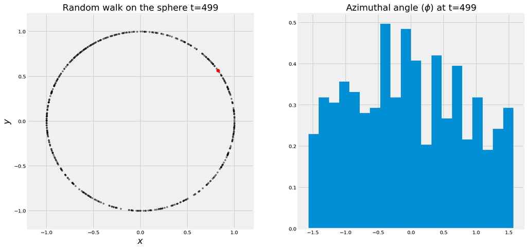

```python
tmax = 500
maxlength = len(str(tmax - 1))

delta = 5/np.pi
d = 2

x = np.zeros(d)
x[0] = 1
x_init = x/np.linalg.norm(x)

X, Y = [], []

for t in range(tmax):
    number_string = str(t).zfill(maxlength)
    x_new = markov_sphere_move(x_init, delta, d)
    x_init = x_new

    X.append(x_new[0])
    Y.append(x_new[1])

    clear_output(wait=True)
    plot2D_markov_sphere((X, Y), x_new, number_string)
```

### Sampling uniform distribution inside the unit ball

To uniformly sample the inside of a ball, we need to sample radial points using distribution:

$$ \pi(r) = d r^{d-1}, \ \ \ 0 < r < 1 $$

We can sample these points through Uniform$([0,1])^{1/d}$, using universality of uniform theorem, which states the following:

- For r.v. $Y = F_X(X)$, we have $F_Y(u) = F_U(u)$ or $Y \sim Uniform([0,1])$.
- For r.v. $Z = F_X^{-1}(U)$, we have $F_Z(u) = F_X(u)$ or $Z \sim dist(X)$.

Indeed, the CDF corresponding to $\pi(r)$ is:

$$ F_R(r) = r^{d} \ \implies F_R^{-1}(u) = u^{1/d} \sim \pi(R) $$

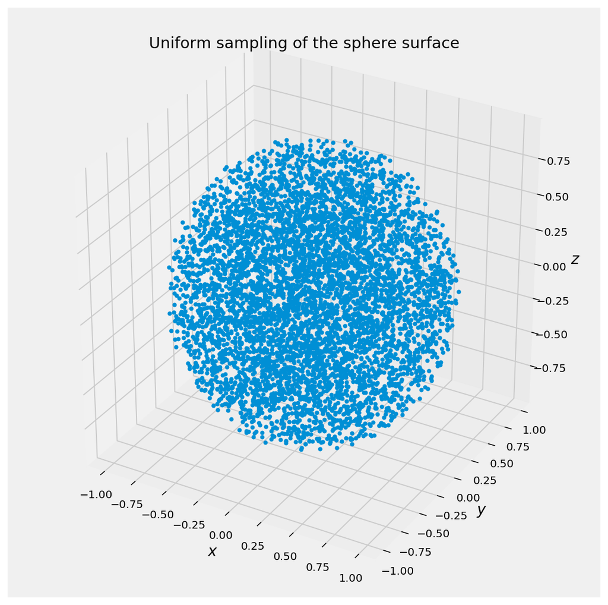

```python
x_list, y_list, z_list = [],[],[]
nsamples = 6000

for sample in range(nsamples):
    x, y, z = random.gauss(0.0, 1.0), random.gauss(0.0, 1.0), random.gauss(0.0, 1.0)
    length = random.uniform(0.0, 1.0) ** (1.0 / 3.0) / np.sqrt(x ** 2 + y ** 2 + z ** 2)
    x, y, z = x * length, y * length, z * length
    x_list.append(x)
    y_list.append(y)
    z_list.append(z)

# graphics output
plot_samples(x_list, y_list, z_list)
```

## Metropolis Acceptance Probability

The essence of Metropolis acceptance probability: perform a random uniform sampling, and accept the new sample with probability:

$$p(a\to b) = \min(1, \pi(b)/\pi(a)),$$

where $a$ is the initial state, $b$ is the new state, and $\pi(a)$ is the probability distribution.

### Generating Samples from Given Distribution

Computationally, to generate a sample from $\pi(x)$ distribution,

- Start from initial state $a$, and randomly (uniformly) move to potential state $b$
- Generate a uniformly distributed random variable $\Upsilon \sim \text{Uniform}([0, 1])$
- If $\Upsilon < \pi(b)/\pi(a),$ accept the move to a new state $b$, otherwise, reject it.

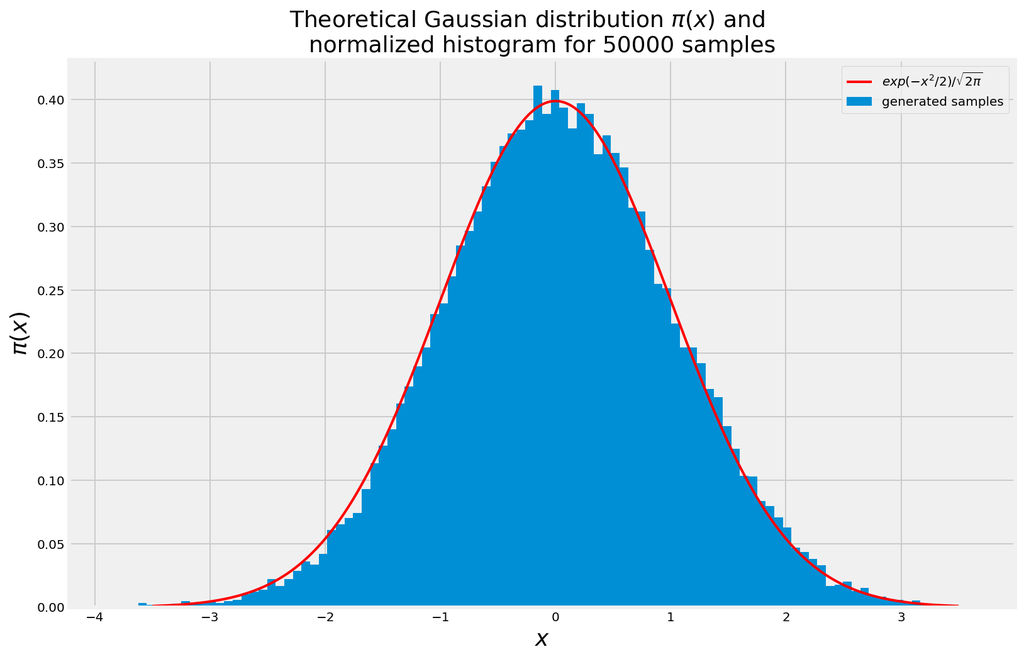

```python
x = 0.0
delta = 0.5
data = []
N = 50000

for k in range(N):
    x_new = x + random.uniform(-delta, delta)
    if random.uniform(0.0, 1.0) < np.exp(- x_new ** 2 / 2.0) / np.exp(- x ** 2 / 2.0):
        x = x_new
    data.append(x)

t = np.linspace(-3.5, 3.5, N)
y = np.exp(- t ** 2 / 2.0) / np.sqrt(2.0 * np.pi)

fig = plt.figure(figsize=(12,8))
plt.hist(data, 100, density = 'True', label="generated samples")
plt.plot(t, y, c='red', linewidth=2.0, label="$exp(-x^2/2)/\sqrt{2\pi}}$")
plt.title('Theoretical Gaussian distribution $\pi(x)$ and \
    \nnormalized histogram for '+str(len(data))+' samples', fontsize = 18)
plt.xlabel('$x$', fontsize = 18)
plt.ylabel('$\pi(x)$', fontsize = 18)
plt.legend(loc="upper right")
plt.show()
```

### Direct Sampling Rejection (Cut) Algorithm

Drop points into rectangle that frames the original distribution.

N.B. Rejections here are related to direct sampling algorithm.

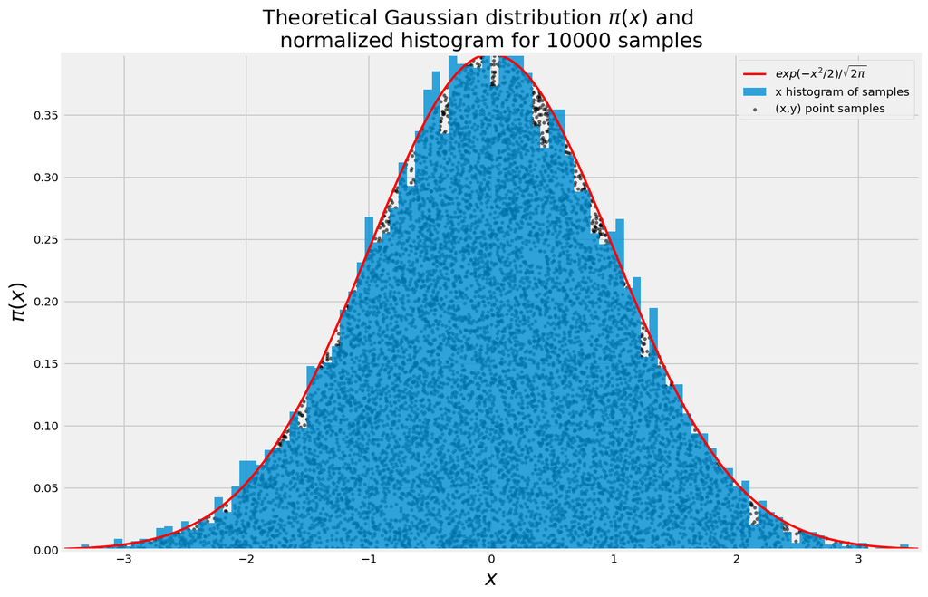

```python
y_max = 1.0 / np.sqrt(2.0 * np.pi)
x_cut = 3.5

n_data = 10000
n_accept = 0
data = []
X, Y = [], []

while n_accept < n_data:
    y = random.uniform(0.0, y_max)
    x = random.uniform(-x_cut, x_cut)
    if y < np.exp( - x **2 / 2.0) / np.sqrt(2.0 * np.pi):
        n_accept += 1
        data.append(x)
        X.append(x)
        Y.append(y)

t = np.linspace(-3.5, 3.5, N)
yt = np.exp(- t ** 2 / 2.0) / np.sqrt(2.0 * np.pi)

fig = plt.figure(figsize=(12,8))
plt.hist(data, 100, density = 'True', label="x histogram of samples", alpha=0.8)
plt.scatter(X, Y, color='black', marker='.', linewidths=0.1, alpha=0.6, label="(x,y) point samples")

plt.plot(t, yt, c='red', linewidth=2.0, label="$exp(-x^2/2)/\sqrt{2\pi}}$")
plt.title('Theoretical Gaussian distribution $\pi(x)$ and \
    \nnormalized histogram for '+str(len(data))+' samples', fontsize = 18)
plt.xlabel('$x$', fontsize = 18)
plt.ylabel('$\pi(x)$', fontsize = 18)
plt.xlim([-x_cut, x_cut])
plt.ylim([0, y_max])
plt.legend(loc="upper right")
plt.show()
```

### Dealing with inverse square root distribution

This method fails, e.g., for the inverse sqrt distribution, because we don't know what box size to choose. For larger boxes the rejection rate would be very large rendering our algorithm inefficient.

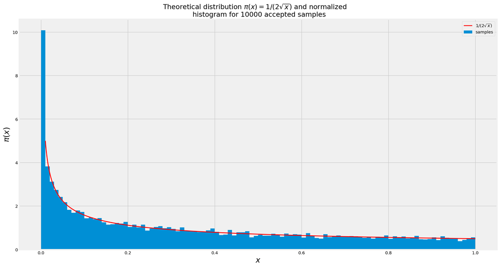

```python
y_max = 100.0
x_cut = 1.0
n_data = 10000
data = []
n_accept = 0

while n_accept < n_data:
    y = random.uniform(0.0, y_max)
    x = random.uniform(0.0, x_cut)
    if y < 1.0 / (2.0 * np.sqrt(x)):
        n_accept += 1
        data.append(x)

plt.hist(data, bins=100, density='True', label="samples")

t = np.linspace(0.01, 1, n_data)
yt = 1.0 / (2.0 * np.sqrt(t))

plt.plot(t, yt, 'red', linewidth = 2, label="$1/(2\sqrt{x})$")
plt.title('Theoretical distribution $\pi(x)={1}/{(2 \sqrt{x})}$ and normalized\
    \n histogram for '+str(n_accept)+' accepted samples',fontsize=16)
plt.xlabel('$x$', fontsize=18)
plt.ylabel('$\pi(x)$', fontsize=18)
plt.legend(loc="upper right")
plt.show()
```

In this respect MC algorithm is better, since the Markov-chain algorithm does not have problems with infinite probability densities, and it doesn't need to specify any box size. In the algorithm below, we perform Markov-chain sampling with Metropolis acceptance probability, and record the maximal value of $y$ and minimal value of $x$. We can observe, that the algorithm is able to move to very small values of $x$ very rapidly.

```
1.118033988749895 0.2 0
1.5816601291513626 0.09993409290022104 22
1.6185645663763883 0.09542890740957022 25
1.8183351618122336 0.07561224534034028 28
2.503283019346062 0.03989514996092425 65
2.917678889509182 0.02936736780233229 92
6.4349821972794485 0.006037335479678996 162
8.20461819139433 0.0037138405811409925 351
11.43801067387845 0.0019109046343637193 353
19.8625713767786 0.0006336786381512249 395
21.59144047431214 0.0005362616919709629 2146
25.396055134178194 0.0003876211682893871 4842
28.636065838491422 0.0003048690266254095 5027
47.04539493008182 0.00011295508101449858 16628
62.730144833635954 6.353125407365656e-05 18826
125.80356246266436 1.5796254771993645e-05 34837
362.78837425885973 1.8994737048805277e-06 39556
```

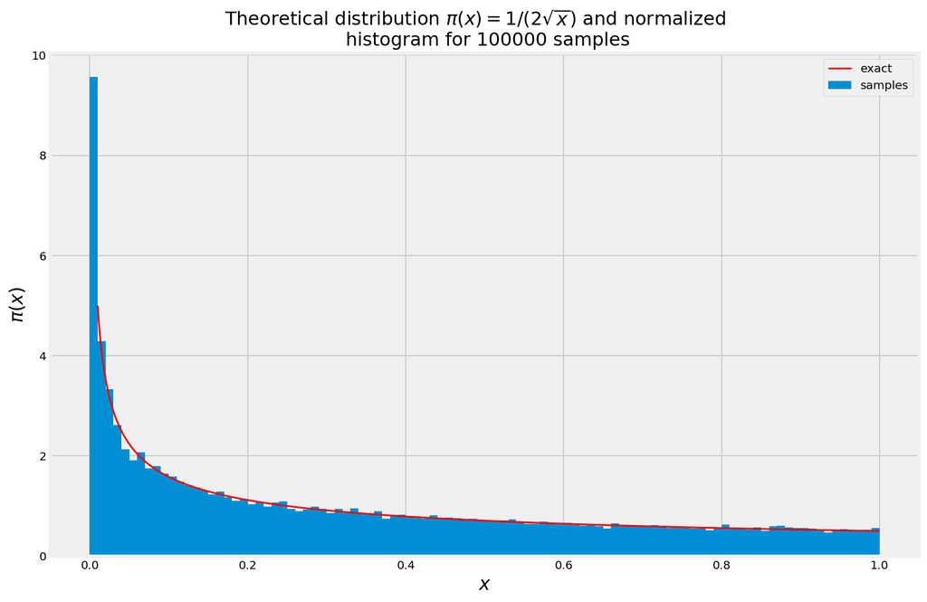

```python
x = 0.2
delta = 0.5
data = []
y_max = 0
n_trials = 100000

for k in range(n_trials):
    x_new = x + random.uniform(-delta, delta)
    if 0.0 < x_new < 1.0:
        if random.uniform(0.0, 1.0) < np.sqrt(x) / np.sqrt(x_new):
            x = x_new
    if 0.5 / np.sqrt(x) > y_max:
        y_max = 0.5 / np.sqrt(x)
        print(y_max, x, k)
    data.append(x)


t = np.linspace(0.01, 1, n_data)
yt = 1.0 / (2.0 * np.sqrt(t))

fig = plt.figure(figsize=(12,8))
plt.hist(data, bins=100, density='True', label="samples")
plt.xlabel('$x$', fontsize=16)
plt.ylabel('$\pi(x)$', fontsize=16)
plt.plot(t, yt, linewidth=1.5, color='r', label="exact")
plt.title('Theoretical distribution $\pi(x)={1}/{(2 \sqrt{x})}$ and normalized\
    \n histogram for ' + str(len(data)) + ' samples', fontsize=16)
plt.legend(loc="upper right")
plt.show()
```

## Tower Sampling Method (rejection free)

Assume that the probability to do either of the activities $(a, b, c, d)$ is $\pi_a, \pi_b, \pi_c, \pi_d$. Then we can use the direct sampling "cut" algorithm discussed above, to determine which activity to select. We simply throw a point into the rectangle that contains given the probabilities, and select the activity, if it is below the "curve". However, this method may have a high rejection rate. That is why it is more efficient to use the rejection free tower sampling algorithm. In this algorithm, we place probabilities on top of each other, like in a tower, and throw a point uniformly into this tower.

```python
def bisection_search(eta, w_cumulative):
    """Bisection search to find the bin corresponding to eta."""
    kmin = 0
    kmax = len(w_cumulative)
    while True:
        k = int((kmin + kmax) / 2)
        if w_cumulative[k] < eta:
            kmin = k
        elif w_cumulative[k - 1] > eta:
            kmax = k
        else:
            return k - 1

def tower_sample(weights):
    """Sample an integer number according to weights."""
    sum_w = sum(weights)
    w_cumulative = [0.0]

    for l in range(len(weights)):
        w_cumulative.append(w_cumulative[l] + weights[l])

    eta = random.random() * sum_w
    sampled_choice = bisection_search(eta, w_cumulative)
    return sampled_choice
```

```python
weights = [0.4, 0.3, 0.8, 0.1, 0.2]
n_samples = 20
for sample in range(n_samples):
    print(tower_sample(weights), end="--")
```

```
1--3--2--4--0--0--1--3--2--1--4--1--2--2--2--1--2--2--2--2--
```

## Walker Algorithm

Although the tower sampling algorithm is rejection free it is not optimal. That is why we will consider Walker algorithm. In this algorithm, assume probabilities are boxes of unit width and height that is equal to the probability. The algorithm goes as follows:

- First compute the average probability
- Put the largest box on top of the smallest box, and return the part above the average line back to its place
- Continue the procedure above until all boxes are of average height, and at most two boxes are in each place
- Sample a point into these boxes to determine the activity

However, Walker algorithm is optimal for discrete distributions.

```
[(0.05, 4, 3), (0.09999999999999998, 3, 1), (0.1, 2, 1), (0.17999999999999997, 1, 0), (0.19999999999999998, 0, 0)]
```

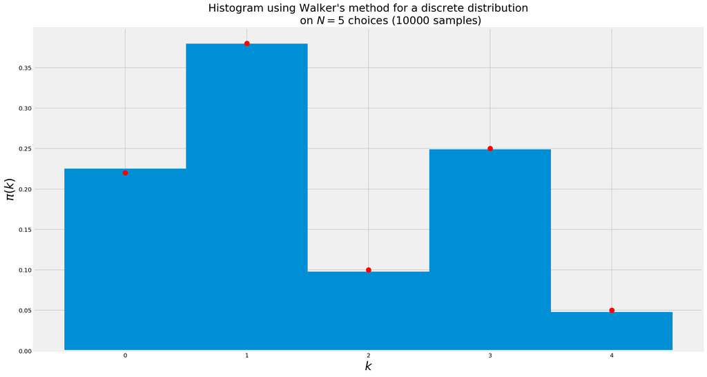

```python
# There are N=5 options with probability pi(a)=[prob, number]

N = 5

pi = [[1.1 / 5.0, 0], [1.9 / 5.0, 1], [0.5 / 5.0, 2], [1.25 / 5.0, 3], [0.25 / 5.0, 4]]

x_val = [a[1] for a in pi]
y_val = [a[0] for a in pi]

# average probability
pi_mean = sum(y_val) / float(N)

long_s = []
short_s = []

for p in pi:
    if p[0] > pi_mean:
        long_s.append(p)
    else:
        short_s.append(p)

table = []
for k in range(N - 1):
    e_plus = long_s.pop()
    e_minus = short_s.pop()
    table.append((e_minus[0], e_minus[1], e_plus[1]))
    e_plus[0] = e_plus[0] - (pi_mean - e_minus[0])
    if e_plus[0] < pi_mean:
        short_s.append(e_plus)
    else:
        long_s.append(e_plus)

if long_s:
    table.append((long_s[0][0], long_s[0][1], long_s[0][1]))
else:
    table.append((short_s[0][0], short_s[0][1], short_s[0][1]))

print(table)

samples = []
n_samples = 10000

for k in range(n_samples):
    Upsilon = random.uniform(0.0, pi_mean)
    i = random.randint(0, N - 1)
    if Upsilon < table[i][0]:
        samples.append(table[i][1])
    else:
        samples.append(table[i][2])

plt.figure()
plt.hist(samples, bins=N, range=(-0.5, N - 0.5), normed=True)
plt.plot(x_val, y_val, 'ro', ms=8)
plt.title("Histogram using Walker's method for a discrete distribution\n\
             on $N=$" + str(N) + " choices (" + str(n_samples) + " samples)", fontsize=18)
plt.xlabel('$k$', fontsize=20)
plt.ylabel('$\pi(k)$', fontsize=20)
plt.show()
```

### Tower Sampling Continuum Limit: Universality of Uniform

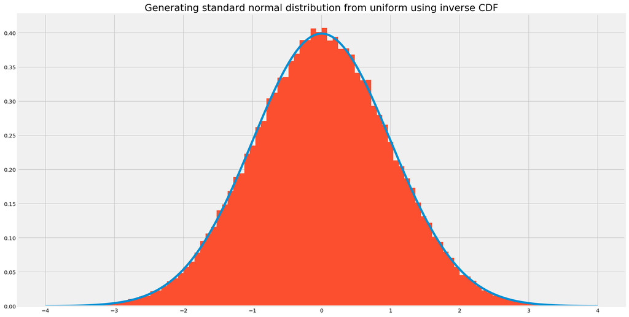

```python
import scipy.special

n_trials = 100000
data = []

for trial in range(n_trials):
    Upsilon = random.uniform(0.0, 1.0)
    x = np.sqrt(2.0) * scipy.special.erfinv(2.0 * Upsilon - 1.0)
    data.append(x)

t = np.linspace(-4, 4, n_trials)

plt.plot(t, np.exp( - t **2 / 2.0) / np.sqrt(2.0 * np.pi))
h = plt.hist(data, bins=100, range=(-4, 4), density=True)
plt.title("Generating standard normal distribution from uniform using inverse CDF", fontsize=18)
plt.show()
```

### Inverse square root distribution revised

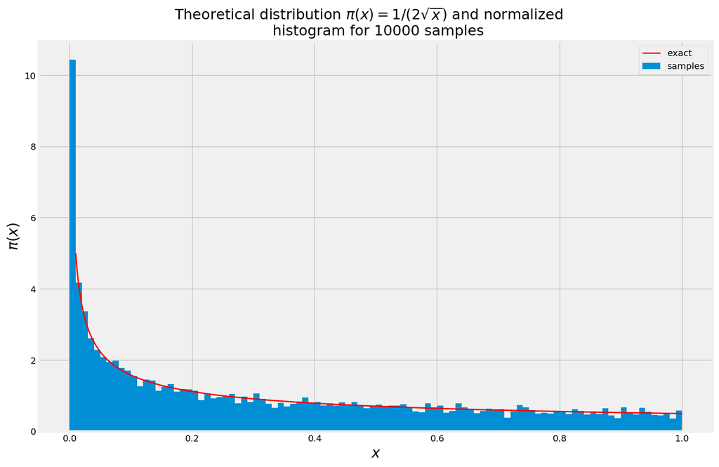

```python
gamma = -0.5
n_trials = 10000
data = []

for _ in range(n_trials):
    u = random.uniform(0, 1)
    x = u ** (1.0/(gamma + 1.0))
    data.append(x)


t = np.linspace(0.01, 1, n_data)
yt = 1.0 / (2.0 * np.sqrt(t))

fig = plt.figure(figsize=(12,8))
plt.hist(data, bins=100, density='True', label="samples")
plt.xlabel('$x$', fontsize=16)
plt.ylabel('$\pi(x)$', fontsize=16)
plt.plot(t, yt, linewidth=1.5, color='r', label="exact")
plt.title('Theoretical distribution $\pi(x)={1}/{(2 \sqrt{x})}$ and normalized\
    \n histogram for ' + str(len(data)) + ' samples', fontsize=16)
plt.legend(loc="upper right")
plt.show()
```

## Calculation of High Dimensional Integrals Using Monte Carlo Methods

### Volume of the $d$-dimensional hypersphere $V_\text{d}(r)$

- Surface area of $d$-sphere, boundary of $(d+1)$-ball, of radius $r$: $ \ \ \ A_d(r)=\frac{2\pi^{(d+1)/2}}{\Gamma\left(\frac{d+1}{2}\right)}r^{d} = (2\pi r)V_{d-1}(r)$
- Volume of $d$-ball of radius $r$: $ \ \ \ V_d(r)=\int_0^r S_{d-1}(r') \text{d}r' = \frac{\pi^{d/2}}{\Gamma\left(\frac{d}{2}+1\right)}r^d = \frac{r}{d}A_{d-1}(r) \sim \frac{1}{\sqrt{\pi d}}\left(\frac{2\pi e}{d}\right)^{d/2}r^d $

### Markov-chain Monte Carlo program to compute the quantity:

$Q(d) \equiv 2V_{d, sph}(1)/V_{d, cyl}(1) = V_{d, sph}(1)/V_{d-1, sph}(1) = \sqrt{\pi} \frac{\Gamma\left(\frac{d+1}{2}\right)}{\Gamma\left(\frac{d}{2}+1\right)}$

```python
# samples points (x, y) inside the unit disk, rather than inside the square
# at each step, sample a new value of z as random.uniform(-1.0, 1.0), and count as a "hit" if x^2 + y^2 + z^2 < 1.0.

x, y = 0.0, 0.0  # initial position
delta = 0.5      # step size

N_R = 400000      # number of steps
N_C = 0          # number of times we are inside the circle

for _ in range(N_R):
    z = random.uniform(-1.0, 1.0)
    dx, dy = random.uniform(-delta, delta), random.uniform(-delta, delta)
    if (x + dx)**2 + (y + dy)**2 < 1.0:
        x, y = x + dx, y + dy

    if x ** 2 + y ** 2 + z ** 2 < 1.0:
        N_C += 1

Q_3 = 2*N_C/N_R
print("<Q(3)> is:", Q_3)
```

```
<Q(3)> is: 1.33497
```

### Computing $V_{4}(1)$

```python
# sample points (x,y,z) inside the 3D unit sphere.
# at each step, sample a w as random.uniform(-1.0, 1.0), and count as a "hit" if (x^2 + y^2 + z^2 + w^2) < 1.

x, y, z = 0.0, 0.0, 0.0  # initial position
delta = 0.5              # step size

N_R = 400000      # number of steps
N_C = 0          # number of times we are inside the circle

for _ in range(N_R):
    w = random.uniform(-1.0, 1.0)
    dx, dy, dz = random.uniform(-delta, delta), random.uniform(-delta, delta), random.uniform(-delta, delta)
    if (x + dx)**2 + (y + dy)**2 + (z + dz)**2 < 1.0:
        x, y, z = x + dx, y + dy, z + dz

    if x ** 2 + y ** 2 + z ** 2 + w ** 2 < 1.0:
        N_C += 1

Q_4 = 2*N_C/N_R
V_3 = 4*np.pi/3.0
V_4 = V_3 * Q_4
print("Estimated <Q(4)> =", Q_4, ", exact Q(4) =", (np.pi**2/2)/V_3)
print("Estimated <V(4)> =", V_4, ", exact V(4) =", np.pi**2/2)
```

```
Estimated <Q(4)> = 1.17997 , exact Q(4) = 1.1780972450961724
Estimated <V(4)> = 4.942646777941797 , exact V(4) = 4.934802200544679
```

### Computing $V_{d}(1)$

```python
def rand_uniform_sphere(d, N):
    """ Uniformly samples points inside d-D unit sphere.
        At each iteration we modify only one component.
        Returns: array of N samples (rows) and d columns
    """
    x = [0.0]*d
    old_radius_square = 0.0
    delta = 0.5
    samples = []
    rads = []
    for _ in range(N):
        k = random.randint(0, d - 1)
        step = random.uniform(-delta, delta)
        x_old_k = x[k]
        x_new_k = x_old_k + step
        new_radius_square = old_radius_square + x_new_k ** 2 - x_old_k ** 2
        if new_radius_square < 1.0:
            x[k] = x_new_k
            old_radius_square = new_radius_square
        samples += x  # appending lists in iteration causes problems, this is why we extend list
        rads.append(np.sqrt(old_radius_square))
    return np.array(samples).reshape(-1, d), rads


def Q(d, N):
    D = d-1
    x = [0.0]*D
    old_radius_square = 0.0
    delta = 0.5
    samples = []
    N_C = 0
    for _ in range(N):
        z = random.uniform(-1, 1)
        k = random.randint(0, D - 1)
        step = random.uniform(-delta, delta)
        x_old_k = x[k]
        x_new_k = x_old_k + step
        new_radius_square = old_radius_square + x_new_k ** 2 - x_old_k ** 2
        if new_radius_square < 1.0:
            x[k] = x_new_k
            old_radius_square = new_radius_square
        if old_radius_square + z**2 < 1:
            N_C += 1
    return 2*N_C/float(N)


def vol_sphere_exact(d):
    return np.pi**(d/2.0)/np.math.gamma(d/2.0 + 1.0)


def vol_sphere(d, N):
    V_2 = np.pi
    if d == 2:
        return V_2
    elif d < 2:
        raise ValueError("Number of dimensions should be no less than 2!!")
    else:
        V_d = V_2

    for i in range(3, d+1):
        V_d *= Q(i, N)

    V_d_exact = vol_sphere_exact(d)
    error = round(100*(V_d - V_d_exact)/V_d_exact, 4)
    print(f"For d = {d}, estimated <V_d> = {V_d}, exact V_d = {V_d_exact}, error = {error}%")
    return V_d


V_d = vol_sphere(200, 100000)
```

```
For d = 200, estimated <V_d> = 3.8772003235439317e-109, exact V_d = 5.5588328420278045e-109, error = -30.2515%
```

```python
diffs = []
Ns = [10**k for k in range(2, 7)]
for N in Ns:
    V_d = vol_sphere(20, N)
    V_d_exact = vol_sphere_exact(20)
    diffs.append(V_d_exact - V_d)
```

```
For d = 20, estimated <V_d> = 0.07570073161162973, exact V_d = 0.02580689139001405, error = 193.3353%
For d = 20, estimated <V_d> = 0.028999238953228458, exact V_d = 0.02580689139001405, error = 12.3701%
For d = 20, estimated <V_d> = 0.0286578096454377, exact V_d = 0.02580689139001405, error = 11.0471%
For d = 20, estimated <V_d> = 0.02580766556337265, exact V_d = 0.02580689139001405, error = 0.003%
For d = 20, estimated <V_d> = 0.02556980933464768, exact V_d = 0.02580689139001405, error = -0.9187%
```

### Checking that samples are uniform and correctly distributed in $r$

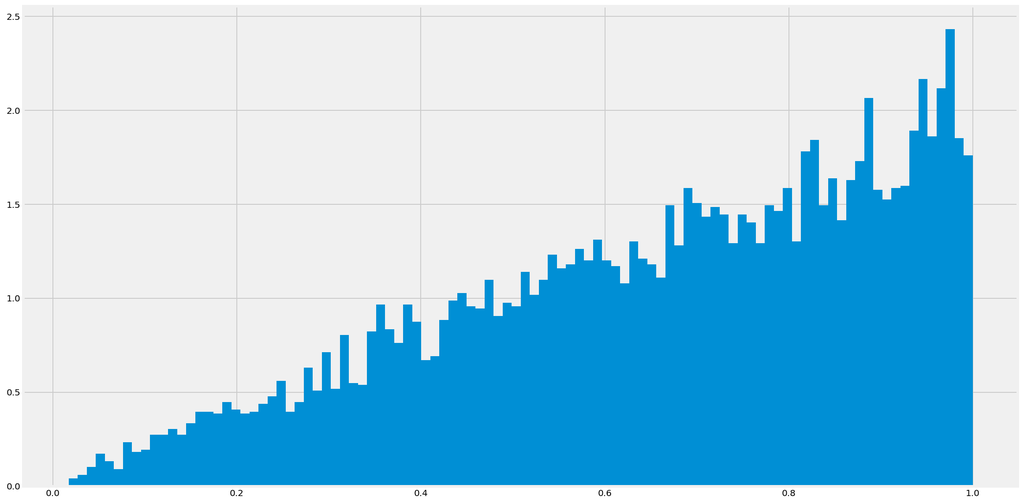

```python
samples, rads = rand_uniform_sphere(2, 10000)

h = plt.hist(rads, bins=100, density=True)
```

```
(-1.100751090701076,
 1.100095033552221,
 -1.0975059925356443,
 1.0956400042932728)
```

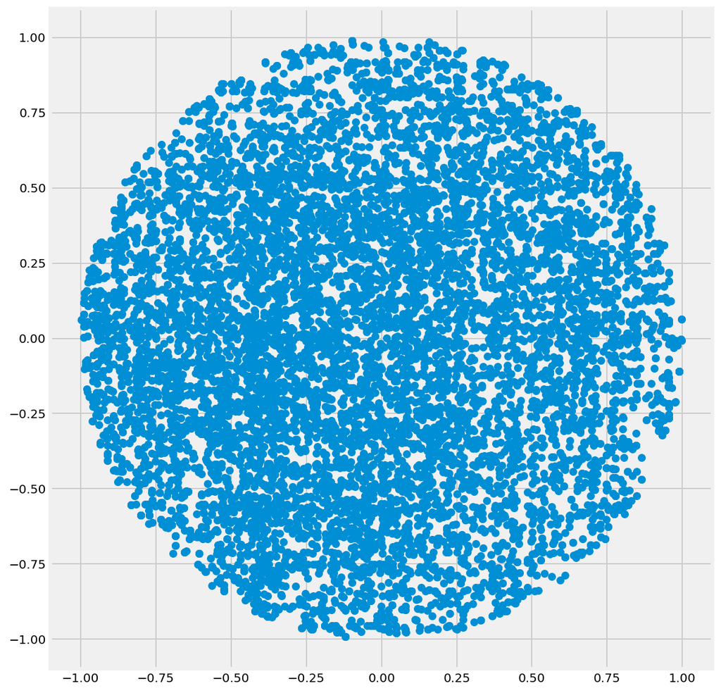

```python
s = plt.scatter(samples[:, 0], samples[:, 1])
plt.axis('scaled')
```

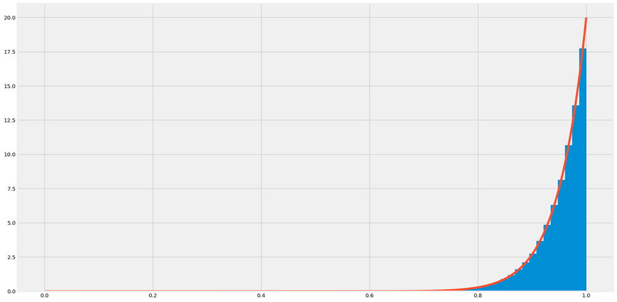

```python
N = 1000000
samples, rads = rand_uniform_sphere(20, N)
t = np.linspace(0, 1, N)

h = plt.hist(rads, bins=50, density=True)
plt.plot(t, 20*t**19)
```

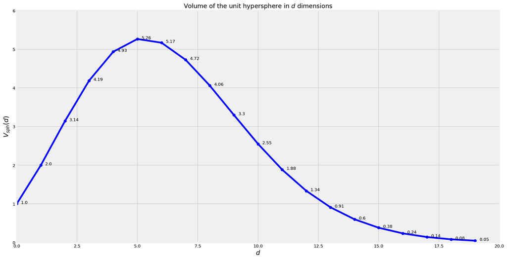

```python
volume, dimension = [], []

def V_sph(dim):
    return np.pi ** (dim / 2.0) / np.math.gamma(dim / 2.0 + 1.0)

for d in range(0,20):
    dimension.append(d)
    volume.append(V_sph(d))

plt.plot(dimension, volume, 'bo-')
plt.title('Volume of the unit hypersphere in $d$ dimensions')
plt.xlabel('$d$', fontsize = 15)
plt.ylabel('$V_{sph}(d)$', fontsize = 15)
plt.xlim(0,20)
plt.ylim(0,6)
for i in range(0,20):
    plt.annotate(round(volume[i],2), (dimension[i], volume[i]), xytext=(10, 0), ha='left',
                textcoords='offset points')
plt.grid(True)
```

### Convert jupyter notebook into the html file with in a given format

```python
notebook_file = r"P3_Sampling_and_Integration.ipynb"
html_converter(notebook_file)
```